# Survey Analysis

Allison Bailey

2/28/2020

```r
# Attach libraries to be able to conduct Q. 2 on the assignment (PCA)
library(tidyverse)
library(janitor)
library(naniar)
library(VIM)
library(skimr)
library(ggfortify)
library(here)

# Read in the data.
land_conservation <- read_csv("DeGoliaSurvey_PSETXLS.csv")

land_clean <- land_conservation %>%
  clean_names() %>%
  select(-captrade, -renewables)
```

#### **Environmental Programs Support Survey Analysis**

In 2017, UCSB-Bren PhD candidate, Alexander DeGolia, published his dissertation “Choosing Green: Explaining Motivations Across Different Environmental Behaviors”.[1] Part of the research included an extensive survey to California residence to evaluate motivations that drive support or opposition towards environmental policies and programs. The data collected on each residence was broken down into age, gender, education level, income level, and political affiliation. Each resident was asked their level of support (Strongly Oppose, Mostly Oppose, Neutral, Mostly Support, Strongly Support) for three California environmental programs: Cap and Trade, Land Conservation, and Renewable Energy.

A Principal component analysis (PCA) was conducted to evaluate the variables in the survey that were most correlated with the levels of support for the Land Conservation Program.

```r
# Now let's do PCA. Use the 'prcomp()' function
# land_pca <- prcomp(land_clean, scale = TRUE) gives us error!

# We have errors.  Let's explore missingness!

summary(land_clean)
```

```
##  landconservation   education         income           age
##  Min.   :1.000    Min.   :1.000   Min.   :1.000   Min.   :18.00
##  1st Qu.:3.000    1st Qu.:3.000   1st Qu.:2.000   1st Qu.:26.00
##  Median :4.000    Median :4.000   Median :3.000   Median :31.00
##  Mean   :4.008    Mean   :3.536   Mean   :3.386   Mean   :33.67
##  3rd Qu.:5.000    3rd Qu.:4.000   3rd Qu.:4.000   3rd Qu.:38.00
##  Max.   :5.000    Max.   :5.000   Max.   :6.000   Max.   :71.00
##                                   NA's   :1
##      gender         partyid
##  Min.   :1.000   Min.   :1.000
##  1st Qu.:1.000   1st Qu.:2.000
##  Median :1.000   Median :2.000
##  Mean   :1.395   Mean   :2.297
##  3rd Qu.:2.000   3rd Qu.:3.000
##  Max.   :2.000   Max.   :4.000
##
```

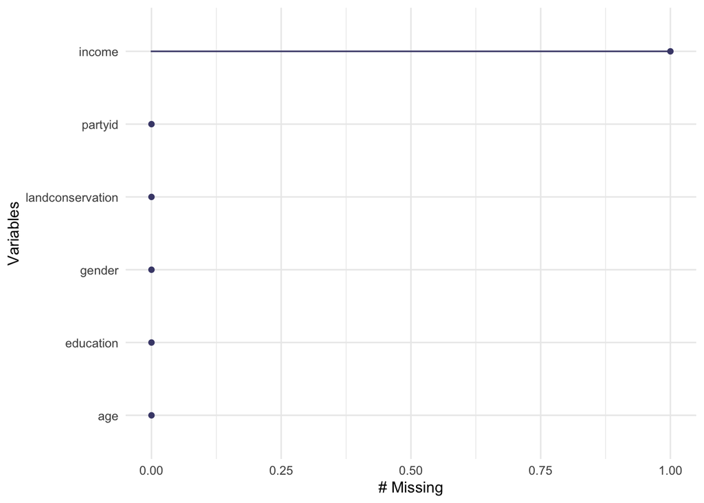

```r
# There is 1 NA in the income column
# double check with gg_miss_var
gg_miss_var(land_clean)
```

```r
# Let's drop that one NA using drop_NA()

land_ready <- land_clean %>%
  drop_na()

# Now let's try our PCA again....
land_pca <- prcomp(land_ready, scale = TRUE)
```

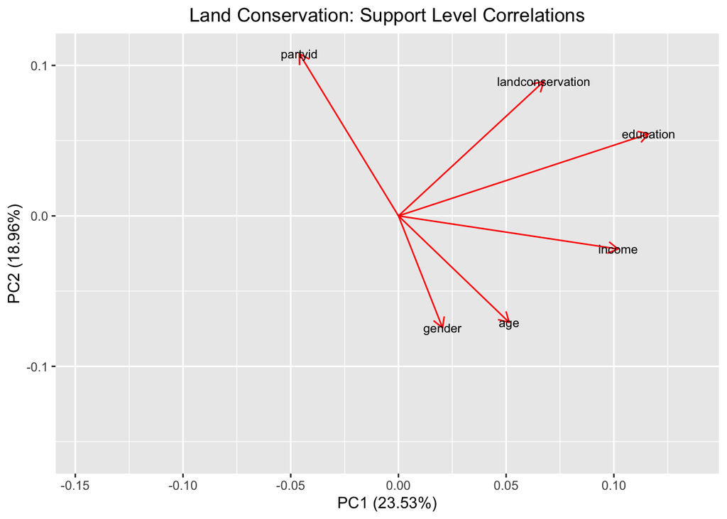

```r
# Now we are ready to plot our PCA..

land_biplot <- autoplot(land_pca,
                      colour = NA,
                      loadings.label = TRUE,
                      loadings.label.size = 3,
                      loadings.label.colour = "black",
                      loading.label.repel = TRUE) +
  ggtitle("Land Conservation: Support Level Correlations") +
  theme(plot.title = element_text(hjust = 0.5))

land_biplot
```

#### **References**

[1]Alexander DeGolia et al., 2017, “Choosing Green: Explaining Motivations Across Different Environmental Behaviors”, data availalbe on UCSB gauchspace: https://gauchospace.ucsb.edu/courses/mod/resource/view.php?id=2921098 [Accessed 02/01/2020]